# Using the absmaps package

Will Mackey

2019-02-11

The `absmaps` package does four things to simplify the process of mapping Australian data:

1. **downloads** particular spatial data (`maps`) from the Australian Bureau of Statistics (`abs`);
   - This presently includes `sa1`, `sa2`, `sa3`, `sa4`, `gcc`, `ra` and `state` ASGS data from 2011 and 2016, with more to be included with time.
2. **compresses** the original ‘shapefile’ data to something more manageable, without losing important detail;
3. **converts** the shapefile data to an `sf` (simple feature) object;
4. **saves** and **loads** the resulting `sf` object for easy use with `dplyr` and `ggplot`.

Before we get into the ‘what problem is this package solving’ details, let’s look at some examples so that you can copy-paste into your own console and replicate out-of-the-box.

## Just show me how to make a map with this package

```r
library(absmaps)

load_absmaps("sa4", year = 2016, download = TRUE)
```

The `sf` object contains one observation per area (in this example, one observation per `sa4`). It stores the geometry information in the `geometry` variable, which is a list describing the area’s polygon.

```r
head(sa42016)
```

```
#> Simple feature collection with 6 features and 9 fields
#> geometry type:  MULTIPOLYGON
#> dimension:      XY
#> bbox:           xmin: 140.9993 ymin: -37.50503 xmax: 153.3948 ymax: -28.96997
#> epsg (SRID):    4283
#> proj4string:    +proj=longlat +ellps=GRS80 +towgs84=0,0,0,0,0,0,0 +no_defs
#>   sa4_code                         sa4 gcc_code            gcc state_code
#> 1      101              Capital Region    1RNSW    Rest of NSW          1
#> 2      102               Central Coast    1GSYD Greater Sydney          1
#> 3      103                Central West    1RNSW    Rest of NSW          1
#> 4      104     Coffs Harbour - Grafton    1RNSW    Rest of NSW          1
#> 5      105          Far West and Orana    1RNSW    Rest of NSW          1
#> 6      106 Hunter Valley exc Newcastle    1RNSW    Rest of NSW          1
#>             state   areasqkm cent_lat cent_long
#> 1 New South Wales  51895.563 149.2450 -35.56480
#> 2 New South Wales   1681.072 151.2855 -33.30797
#> 3 New South Wales  70297.060 148.3558 -33.21697
#> 4 New South Wales  13229.758 152.7739 -29.81603
#> 5 New South Wales 339363.693 145.0269 -30.98611
#> 6 New South Wales  21491.291 150.9849 -32.35481
#>                         geometry
#> 1 MULTIPOLYGON (((150.3113 -3...
#> 2 MULTIPOLYGON (((151.315 -33...
#> 3 MULTIPOLYGON (((150.6107 -3...
#> 4 MULTIPOLYGON (((153.2785 -2...
#> 5 MULTIPOLYGON (((150.1106 -3...
#> 6 MULTIPOLYGON (((152.3165 -3...
```

We do all this so we can create maps. And from there, plotting a map via `ggplot` and `geom_sf` is simple.

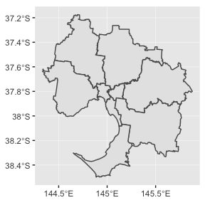

```r
map <-
sa42016 %>%
  filter(gcc == "Greater Melbourne") %>%   # let's just look Melbourne
  ggplot() +
  geom_sf(aes(geometry = geometry))  # use the geometry variable

map
```

The `load_absmaps` package also calculates the centorids of each area, and we can add these points to the map with the `cent_lat` and `cent_long` variables using `geom_point`.

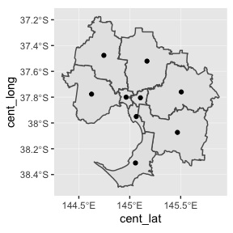

```r
map <-
sa42016 %>%
  filter(gcc == "Greater Melbourne") %>%   # let's just look Melbourne
  ggplot() +
  geom_sf(aes(geometry = geometry)) +   # use the geometry variable
  geom_point(aes(cent_lat, cent_long))  # use the centroid lat and longs

map
```

Cool. But this all looks a bit ugly, and we can clear it up using `ggplot` tweaks. See the comments on each line for its objective. Also note that we’re filling the areas by their `areasqkm` size (we’ll replace this with more interesting data in the next section).

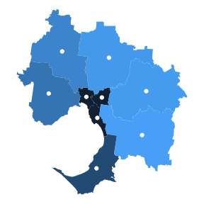

```r
map <-
sa42016 %>%
  filter(gcc == "Greater Melbourne") %>%   # let's just look Melbourne
  ggplot() +
  geom_sf(aes(geometry = geometry,  # use the geometry variable
              fill = areasqkm),     # fill by area size
          lwd = 0,                  # remove borders
          show.legend = FALSE) +    # remove legend
  geom_point(aes(cent_lat,
                 cent_long),        # use the centroid lat and longs
             colour = "white") +    # make the points white
  theme_void() +                    # clears other plot elements
  coord_sf(datum = NA)              # fixes a gridline bug in theme_void()

map
```

## Joining with actual data

At some point, we’ll want to join our spatial data with data-of-interest. The variables in our mapping data—stating the numeric code and name of each area and parent area—will make this *relatively* easy.

For example: we have a simple dataset of the unemployment rate in each `sa4` in each `year` (conveniently retrieved using the `readabs` [package](https://cran.r-project.org/web/packages/readabs/readabs.pdf)).

```r
# Read data in
ue_data <- read_csv("data/ue_data.csv")
# This data contains a variable of sa4 that can be joined to the sa42016 set:
ue_data <- ue_data %>% left_join(sa42016)
```

Now that we have a tidy dataset with 1) the unemployment data we want to plot, and 2) the geometry of the areas, we can plot unemployment rates by area:

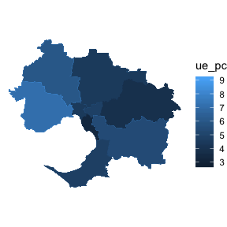

```r
map <-
ue_data %>%
  filter(gcc == "Greater Melbourne") %>%   # let's just look Melbourne
  ggplot() +
  geom_sf(aes(geometry = geometry,  # use the geometry variable
              fill = ue_pc),        # fill by unemployment rate
          lwd = 0) +                # remove borders
  theme_void() +                    # clears other plot elements
  coord_sf(datum = NA)              # fixes a gridline bug in theme_void()

map
```

Or we could show this as points (with the underlyfing spatial data included for clarity).

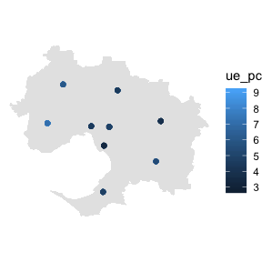

```r
map <-
ue_data %>%
  filter(gcc == "Greater Melbourne") %>% # still looking at Melbourne
  ggplot() +
  geom_sf(aes(geometry = geometry),      # use the geometry variable
          lwd = 0) +                     # remove borders
  geom_point(aes(cent_lat,
                 cent_long,
                 colour = ue_pc)) +
  scale_size_continuous(limits = c(.1, 10)) +
  theme_void() +                         # clears other plot elements
  coord_sf(datum = NA)                   # fixes a gridline bug in theme_void()

map
```

## Why does this package exist?

The motivation for this package is that maps are cool and fun and are, sometimes, the best way to communicate data. And making maps is `R` with `ggplot` is relatively easy *when you have the right `object`*.

Getting the right `object` is not technically difficult, but requires research into the best-thing-to-do at each of the following steps:

- Find the ASGS ABS spatial-data page and determine the right file to download.
- Read the shapefile into `R` using one-of-many import tools.
- Convert the object into something usable.
- Clean up any inconsistencies and apply consistent variable naming/values across areas and years.
- Find an appropriate compression function and level to optimise output.

For me, at least, finding the correct information and developing the best set of steps was a little bit interesting but mostly tedious and annoying. The `absmaps` package does this for you so you can spend more time making maps, and less time on Stack Overflow, the ABS website, and [lovely-people’s kind-of-confusing blogs](https://www.neonscience.org/dc-open-shapefiles-r).

## How does this package do-the-things-it-does

The `absmaps` package uses four key functions to do-the-things-it-does:

- `utils::download.file` to download shapefile data from the ABS.
- `sf::st_read` to read the shapefile into an `sf` object.
- `rmapshaper::ms_simplify` to nicely compress the `sf` object.
- `readr::write_rds` to write, and `readr::read_rds` to read our nice `sf` objects.

There are a bunch of other fiddley-things on top of that, but those four steps are the ‘workhorse’ functions. A big thanks to people who built them.

If you’re interested, check out `load_absmaps.R` code in the `R/` file. And, of course, if you have a suggestion to improve, please do let me know via an issue at https://github.com/wfmackey/absmaps.